# Presentación

**Integrantes**:

- Antonio Anselmi, Miguel Maximiliano (20200118).

¿Mientras mayor es la cantidad de comidas principales, menor es el control de consumo calórico?

# Análisis Exploratorio de Datos

## Descripción general del dataset

| SCC | count |
| --- | --- |
| no | 2015.0 |
| yes | 96.0 |

La mayoría de los entrevistados no controlan las calorías que consumen

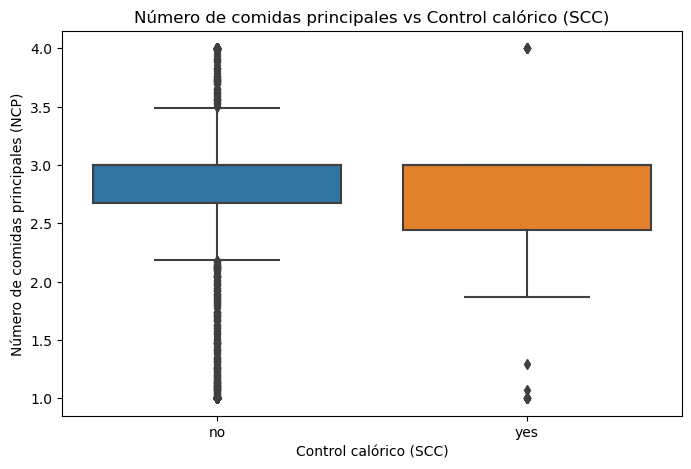

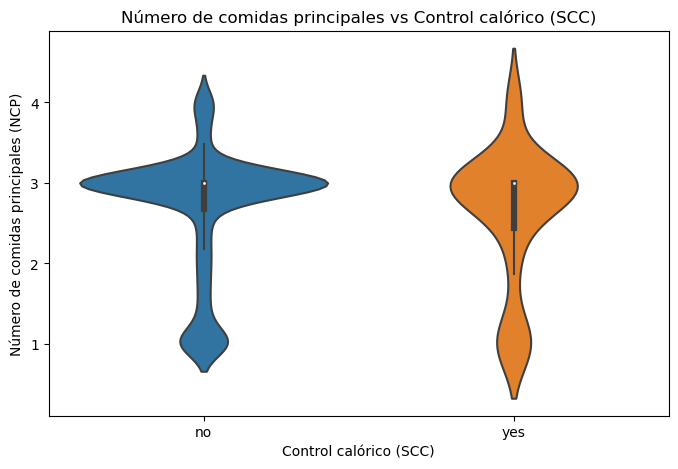

Podemos apreciar que las personas que **si controlan** su consumo de calorías, tienen un mayor rango en la decisión del **Número de comidas principales**. En cambio, los que **no controlan** su consumo de calorías, tienden **en mayoría** , comer **solamente** las 3 comidas principales del día (valor impuesto por la sociedad).

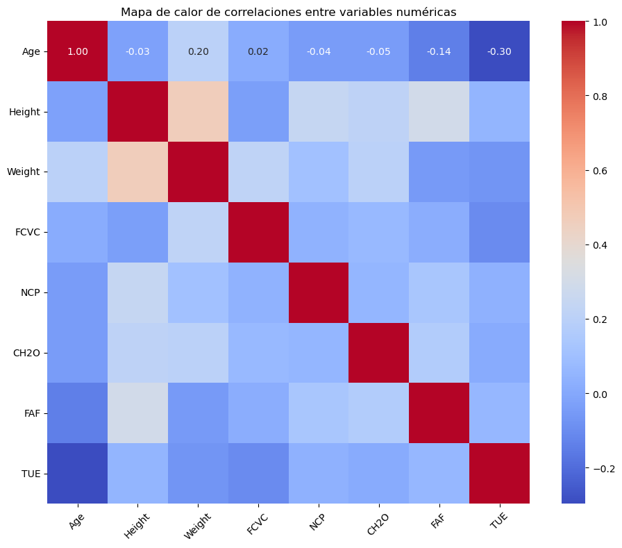

|  | Variable 1 | Variable 2 | Correlación |
| --- | --- | --- | --- |
| 7 | Height | Weight | 0.463136 |

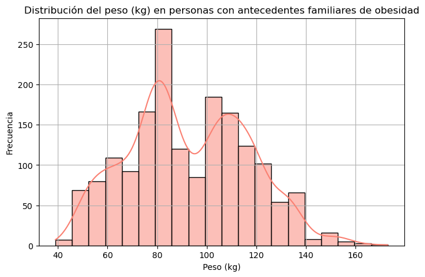

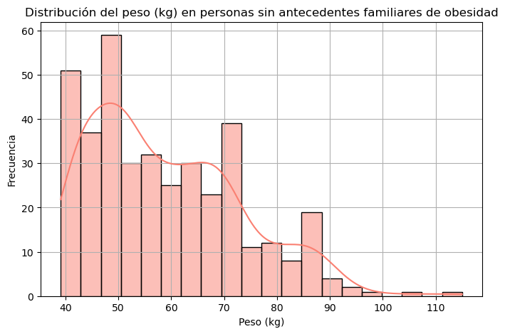

La distribución del peso de las personas que **NO tienen antecedentes familiares con obesidad** , tienen un peso con **asimetría positiva**, es decir que tienden a tener menor peso a comparación de los que **SI tienen antecedentes familiares con obesidad**. Sin embargo es raro que el peso de 40kg sea muy frecuente en el grupo sin antecedentes. Veamos:

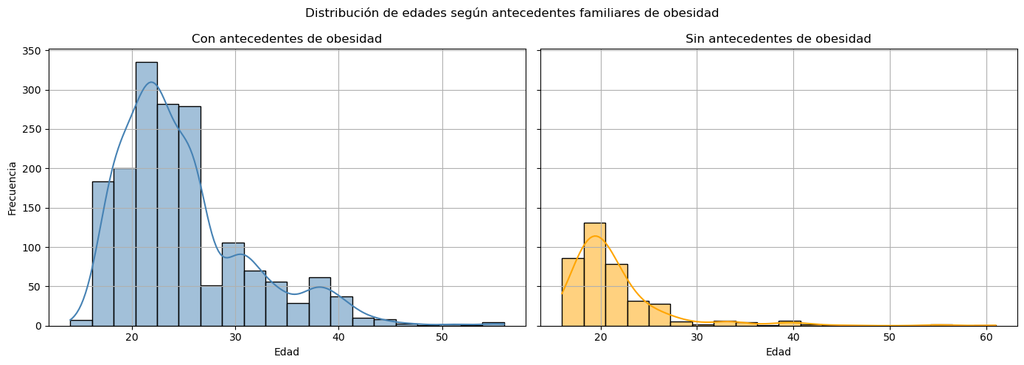

Podemos observar que hay más caso de personas **con antecedentes familiares de obesidad** en este dataset. Tambien hay mayor variación de edad en este grupo respecto al otro.

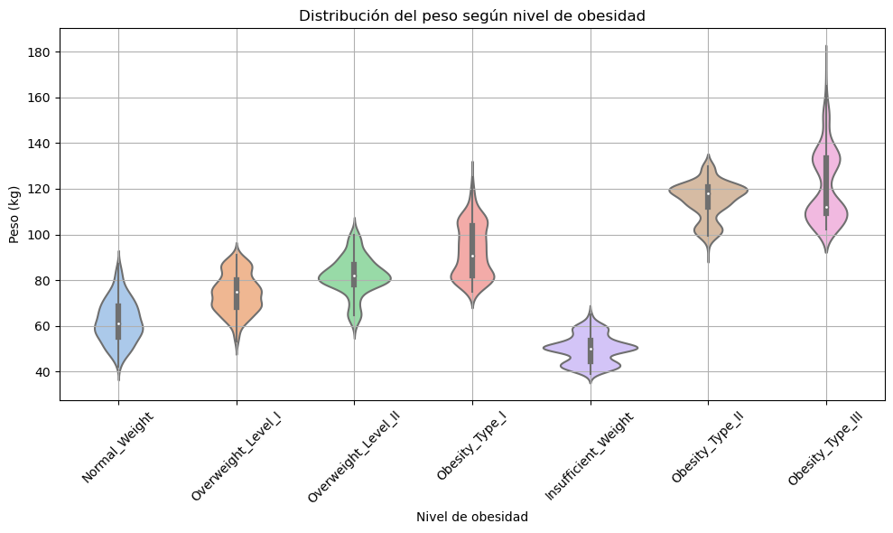

El **peso** es una **variable importante** para entrenar nuestro modelo de clasificación. Podemos observar que hay diferencias entre los pesos de los niveles

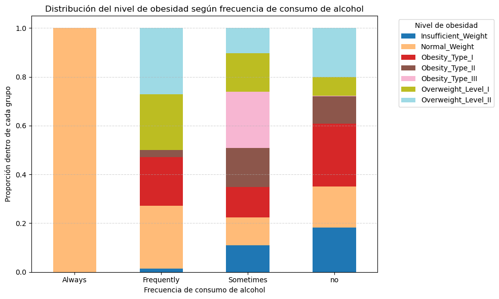

```
Estadístico Chi²: 338.578
Grados de libertad: 18
Valor p: 0.0
✅ Hay una relación significativa entre consumo de alcohol y nivel de obesidad (se rechaza H0)
```

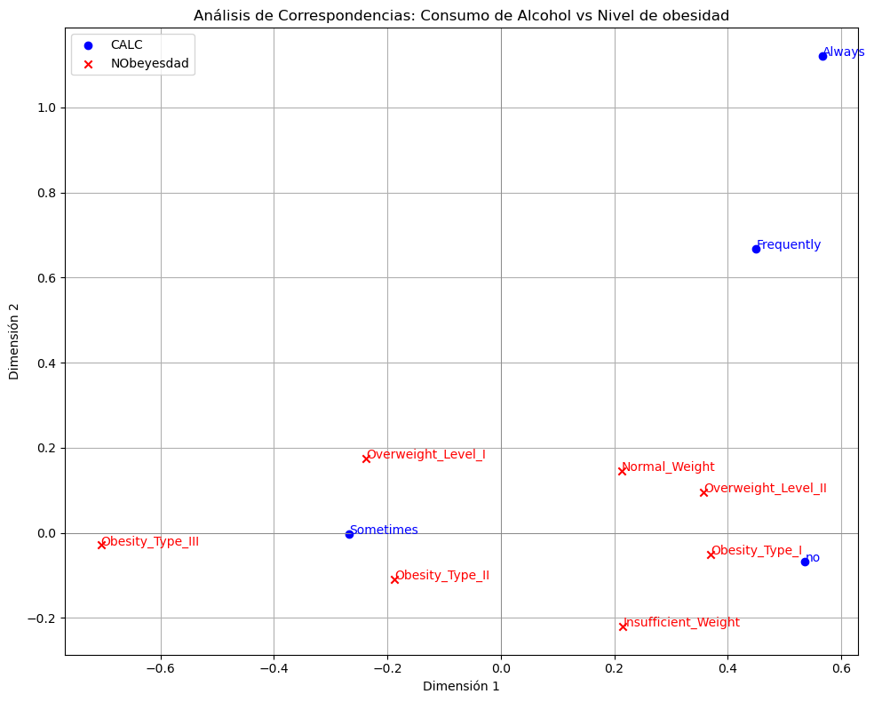

Interesante que los niveles de obesidad más altos no esten necesariamente asociados con el consumo de alcohol en alta frecuencia.

```
NObeyesdad
Insufficient_Weight    0.128849
Normal_Weight          0.135955
Obesity_Type_I         0.166272
Obesity_Type_II        0.140692
Obesity_Type_III       0.153482
Overweight_Level_I     0.137376
Overweight_Level_II    0.137376
Name: NObeyesdad, dtype: float64
```

# Modelamiento

Probaremos los Algoritmos **KNN** , **Random Forest**, **Regresión Logística** y lo tunearemos cada modelo mediante **validación cruzada** de 10 capas, usaremos **F1-Score** para elegir el mejor modelo ya que pondera **Precisión** y **Recall** para no subestimar categorías.  
Tambien repartiremos los datos en proporción de **70:30** para **Entrenamiento** y **Validación** respectivamente.  
**KNN:**

- Se comparará el entrenamiento con **3,5,7** vecinos.
- Se comparará el entrenamiento con pesos diferentes.

**Random Forest:**

- Se comparará el entrenamiento bosques de **100 y 200** arboles de decisión.
- Se variará la máxima profundidad 10 y 20.

```
🔍 RandomForest
Mejores hiperparámetros: {'model__max_depth': 20, 'model__n_estimators': 200}
Mejor F1 promedio en validación cruzada: 0.9451
Evaluación en test set:
                     precision    recall  f1-score   support

Insufficient_Weight       1.00      0.93      0.96        82
      Normal_Weight       0.70      0.88      0.78        86
     Obesity_Type_I       0.97      0.93      0.95       106
    Obesity_Type_II       1.00      0.99      0.99        89
   Obesity_Type_III       1.00      0.99      0.99        97
 Overweight_Level_I       0.84      0.82      0.83        87
Overweight_Level_II       0.97      0.89      0.93        87

           accuracy                           0.92       634
          macro avg       0.93      0.92      0.92       634
       weighted avg       0.93      0.92      0.92       634


🔍 KNN
Mejores hiperparámetros: {'model__n_neighbors': 3, 'model__weights': 'distance'}
Mejor F1 promedio en validación cruzada: 0.8379
Evaluación en test set:
                     precision    recall  f1-score   support

Insufficient_Weight       0.84      0.96      0.90        82
      Normal_Weight       0.73      0.41      0.52        86
     Obesity_Type_I       0.89      0.95      0.92       106
    Obesity_Type_II       0.95      0.97      0.96        89
   Obesity_Type_III       0.99      1.00      0.99        97
 Overweight_Level_I       0.69      0.76      0.72        87
Overweight_Level_II       0.74      0.79      0.77        87

           accuracy                           0.84       634
          macro avg       0.83      0.83      0.83       634
       weighted avg       0.84      0.84      0.83       634


🔍 LogisticRegression
Mejores hiperparámetros: {'model__C': 10.0, 'model__penalty': 'l1'}
Mejor F1 promedio en validación cruzada: 0.7860
Evaluación en test set:
                     precision    recall  f1-score   support

Insufficient_Weight       0.98      1.00      0.99        82
      Normal_Weight       0.71      0.66      0.69        86
     Obesity_Type_I       0.65      0.74      0.69       106
    Obesity_Type_II       0.91      0.96      0.93        89
   Obesity_Type_III       1.00      0.99      0.99        97
 Overweight_Level_I       0.60      0.64      0.62        87
Overweight_Level_II       0.59      0.46      0.52        87

           accuracy                           0.78       634
          macro avg       0.78      0.78      0.78       634
       weighted avg       0.78      0.78      0.78       634


✅ Mejor modelo: RandomForest con F1 CV = 0.9451
```

```
('RandomForest',
 {'modelo': Pipeline(steps=[('preprocessing',
                   ColumnTransformer(transformers=[('num', StandardScaler(),
                                                    Index(['Age', 'Height', 'Weight', 'FCVC', 'NCP', 'CH2O', 'FAF', 'TUE'], dtype='object')),
                                                   ('cat',
                                                    OneHotEncoder(handle_unknown='ignore'),
                                                    Index(['Gender', 'fwo', 'FAVC', 'CAEC', 'SMOKE', 'SCC', 'CALC', 'MTRANS'], dtype='object'))])),
                  ('model',
                   RandomForestClassifier(max_depth=20, n_estimators=200,
                                          random_state=42))]),
  'f1_cv': 0.9450595430677037,
  'params': {'model__max_depth': 20, 'model__n_estimators': 200}})
```

[output not shown]